# Tephritid species identification using CNN

Aaron Harmer

2023-03-01

### Summary

A convolution neural network was trained via transfer learning to identify Tephritidae species using wing images. Threefold cross-validation was used to achieve an accuracy of 93% at predicting class. The initial image set was small, comprising 674 images (459 training, 215 validation) in 30 classes. Classes were defined by genus name or genus & species name.

### Image pre-processing

Images were prepared by:

- Converting colour images to grayscale
- Blurring to reduce image grain noise
- Standardising brightness and contrast to mean = 0.5, contrast range = +-2 standard deviations, with the extreme values clipped
- Squashing and downsampling to 299 by 299 pixels to match the network input filter size

### Model training

Transfer learning was used to retrain an Xception model initially trained on the Imagenet dataset. The model was retrained initially for 148 epochs (early-stopping set) at a learning rate of 1e-04, and then fine-tuned for a further 77 epochs (early-stopping set) at a learning rate of 1e-05.

Images were augmented to prevent over-fitting and increase the robustness of the model to variation in additional images added later. Images augmentations included:

- Random horizontal and vertical shift up to 10%
- Random zoom up to +- 10%
- Random rotation up to +- 25 degrees

### Results

The model achieved a validation accuracy of 93% and validation loss of 0.32 after 77 epochs (Figure 1).

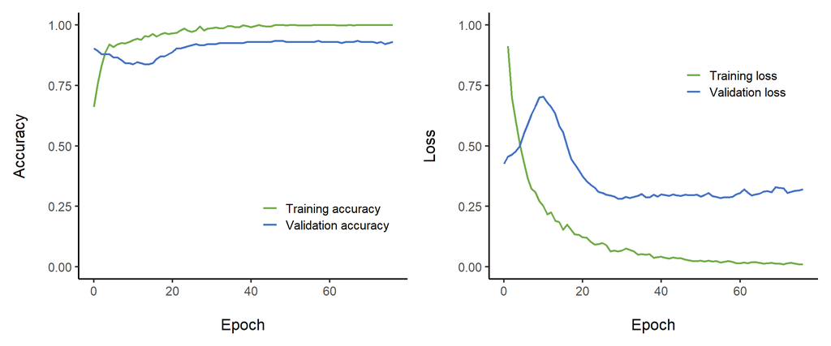

Fig. 1: Accuracy and loss of Xception model after 77 epochs.